# Biostat 203B Homework 1

Due Jan 21 @ 11:59PM

Fengxue Li

## Q1. Git/GitHub

**No handwritten homework reports are accepted for this course.** We work with Git and GitHub. Efficient and abundant use of Git, e.g., frequent and well-documented commits, is an important criterion for grading your homework.

1. Apply for the [Student Developer Pack](https://education.github.com/pack) at GitHub using your UCLA email. You’ll get GitHub Pro account for free (unlimited public and private repositories).
2. Create a **private** repository `biostat-203b-2022-winter` and add `Hua-Zhou` and `maschepps` as your collaborators with write permission.
3. Top directories of the repository should be `hw1`, `hw2`, … Maintain two branches `main` and `develop`. The `develop` branch will be your main playground, the place where you develop solution (code) to homework problems and write up report. The `main` branch will be your presentation area. Submit your homework files (R markdown file `Rmd`, `html` file converted from R markdown, all code and extra data sets to reproduce results) in `main` branch.
4. After each homework due date, teaching assistant and instructor will check out your main branch for grading. Tag each of your homework submissions with tag names `hw1`, `hw2`, … Tagging time will be used as your submission time. That means if you tag your `hw1` submission after deadline, penalty points will be deducted for late submission.
5. After this course, you can make this repository public and use it to demonstrate your skill sets on job market.

## Q2. Data ethics training

This exercise (and later in this course) uses the [MIMIC-IV data](https://mimic-iv.mit.edu), a freely accessible critical care database developed by the MIT Lab for Computational Physiology. Follow the instructions at https://mimic.mit.edu/docs/gettingstarted/ to (1) complete the CITI `Data or Specimens Only Research` course and (2) obtain the PhysioNet credential for using the MIMIC-IV data. Display the verification links to your completion report and completion certificate here. (Hint: The CITI training takes a couple hours and the PhysioNet credentialing takes a couple days; do not leave it to the last minute.)

**report**

https://www.citiprogram.org/verify/?k1676b360-e37f-4950-bc0c-b4ddf9a042ce-46526382

**certification**

https://www.citiprogram.org/verify/?w2a716e01-f093-4bb4-b986-92e71915667b-46526382

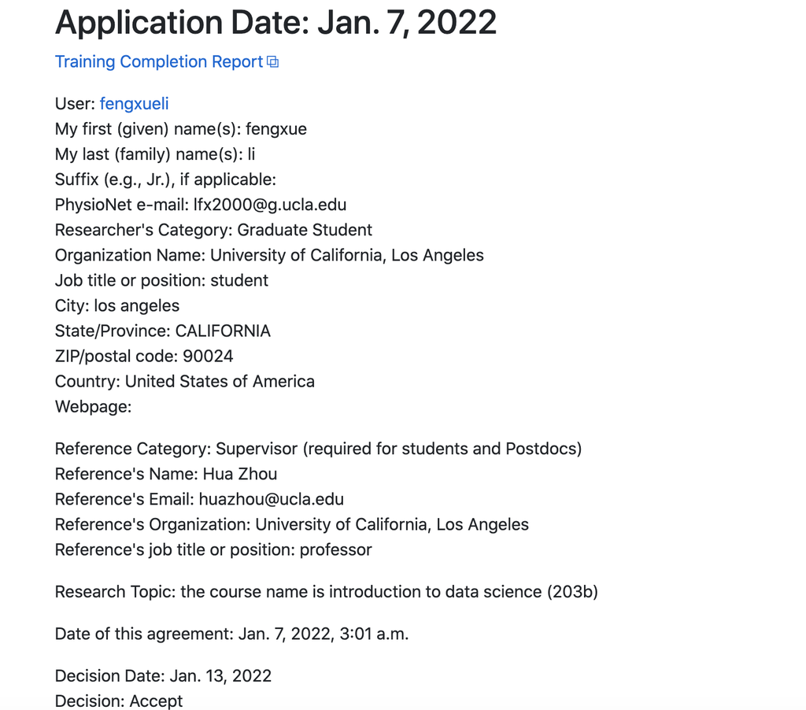

physionet

## Q3. Linux Shell Commands

1. The `/mnt/mimiciv/1.0` folder on teaching server contains data sets from MIMIC-IV. Refer to the documentation https://mimic.mit.edu/docs/iv/ for details of data files.

   ```bash
   pwd
   ls -l /mnt/mimiciv/1.0
   ```

   ```
   ## /home/lifengxue2000/R/wintwe/hw1
   ## total 24
   ## drwxr-xr-x. 2 root root 4096 Jan  4 21:48 core
   ## drwxr-xr-x. 2 root root 4096 Jan  4 21:51 hosp
   ## drwxr-xr-x. 2 root root 4096 Jan  4 21:52 icu
   ## -rw-r--r--. 1 root root  797 Jan  4 21:48 index.html
   ## -rw-r--r--. 1 root root 2518 Jan  4 21:54 LICENSE.txt
   ## -rw-r--r--. 1 root root 2459 Jan  4 21:48 SHA256SUMS.txt
   ```

   Please, do **not** put these data files into Git; they are big. Do **not** copy them into your directory. Do **not** decompress the gz data files. These create unnecessary big files on storage and are not big data friendly practices. Just read from the data folder `/mnt/mimiciv/1.0` directly in following exercises.

   Use Bash commands to answer following questions.
2. Display the contents in the folders `core`, `hosp`, `icu`. Why are these data files distributed as `.csv.gz` files instead of `.csv` (comma separated values) files? Read the page https://mimic.mit.edu/docs/iv/ to understand what’s in each folder.

**solution**

```bash
# display content of mimiciv data
ls -l /mnt/mimiciv/1.0
# display content of core folder
ls -l /mnt/mimiciv/1.0/core
# display content of icu folder
ls -l /mnt/mimiciv/1.0/icu
# display content of hosp folder
ls -l /mnt/mimiciv/1.0/hosp
```

```
## total 24
## drwxr-xr-x. 2 root root 4096 Jan  4 21:48 core
## drwxr-xr-x. 2 root root 4096 Jan  4 21:51 hosp
## drwxr-xr-x. 2 root root 4096 Jan  4 21:52 icu
## -rw-r--r--. 1 root root  797 Jan  4 21:48 index.html
## -rw-r--r--. 1 root root 2518 Jan  4 21:54 LICENSE.txt
## -rw-r--r--. 1 root root 2459 Jan  4 21:48 SHA256SUMS.txt
## total 71472
## -rw-r--r--. 1 root root 17208966 Jan  4 21:48 admissions.csv.gz
## -rw-r--r--. 1 root root      606 Jan  4 21:48 index.html
## -rw-r--r--. 1 root root  2955582 Jan  4 21:48 patients.csv.gz
## -rw-r--r--. 1 root root 53014503 Jan  4 21:48 transfers.csv.gz
## total 2741332
## -rw-r--r--. 1 root root 2350783547 Jan  4 21:54 chartevents.csv.gz
## -rw-r--r--. 1 root root   43296273 Jan  4 21:52 datetimeevents.csv.gz
## -rw-r--r--. 1 root root      55917 Jan  4 21:52 d_items.csv.gz
## -rw-r--r--. 1 root root    2848628 Jan  4 21:52 icustays.csv.gz
## -rw-r--r--. 1 root root       1103 Jan  4 21:52 index.html
## -rw-r--r--. 1 root root  352443512 Jan  4 21:52 inputevents.csv.gz
## -rw-r--r--. 1 root root   37095672 Jan  4 21:52 outputevents.csv.gz
## -rw-r--r--. 1 root root   20567368 Jan  4 21:52 procedureevents.csv.gz
## total 4454012
## -rw-r--r--. 1 root root     430049 Jan  4 21:51 d_hcpcs.csv.gz
## -rw-r--r--. 1 root root   29531152 Jan  4 21:48 diagnoses_icd.csv.gz
## -rw-r--r--. 1 root root     863239 Jan  4 21:48 d_icd_diagnoses.csv.gz
## -rw-r--r--. 1 root root     579998 Jan  4 21:48 d_icd_procedures.csv.gz
## -rw-r--r--. 1 root root      14898 Jan  4 21:48 d_labitems.csv.gz
## -rw-r--r--. 1 root root   11684062 Jan  4 21:51 drgcodes.csv.gz
## -rw-r--r--. 1 root root  515763427 Jan  4 21:51 emar.csv.gz
## -rw-r--r--. 1 root root  476252563 Jan  4 21:48 emar_detail.csv.gz
## -rw-r--r--. 1 root root    2098831 Jan  4 21:51 hcpcsevents.csv.gz
## -rw-r--r--. 1 root root       2325 Jan  4 21:48 index.html
## -rw-r--r--. 1 root root 2091865786 Jan  4 21:50 labevents.csv.gz
## -rw-r--r--. 1 root root   99133381 Jan  4 21:48 microbiologyevents.csv.gz
## -rw-r--r--. 1 root root  422874088 Jan  4 21:48 pharmacy.csv.gz
## -rw-r--r--. 1 root root  501381155 Jan  4 21:51 poe.csv.gz
## -rw-r--r--. 1 root root   24020923 Jan  4 21:48 poe_detail.csv.gz
## -rw-r--r--. 1 root root  367041717 Jan  4 21:49 prescriptions.csv.gz
## -rw-r--r--. 1 root root    7750325 Jan  4 21:48 procedures_icd.csv.gz
## -rw-r--r--. 1 root root    9565293 Jan  4 21:48 services.csv.gz
```

CSV.GZ is a CSV file compressed. CSV file is very big, so it be compressed to be easier to store and send. Core folder include patient stay information. ICU folder include data collected from cilnical information system used within ICU. HOSP folder include hospital level data form patients, like labs and micro information.

3. Briefly describe what bash commands `zcat`, `zless`, `zmore`, and `zgrep` do.

**solution**

`zcat` command can be used to view the compressed file without uncompressing that file.

`zgrep` command can be used to search inside a compressed file. `zegrep` is like `grep` command in uncompressed file

`zless` is used to read gz file and paginate it. `zless` is like `less` in uncompressed file

`zmore` is used to read gz file and paginate it. `zmore` is like `more` in uncompressed file

4. What’s the output of following bash script?

   ```bash
   for datafile in /mnt/mimiciv/1.0/core/*.gz
     do
       ls -l $datafile
     done
   ```

**solution**

this bash script display all the compressed file in core folder

Display the number of lines in each data file using a similar loop.

```bash
for datafile in /mnt/mimiciv/1.0/core/*.gz
  do
   zcat $datafile | wc -l
  done
```

```
## 523741
## 382279
## 2189536
```

5. Display the first few lines of `admissions.csv.gz`. How many rows are in this data file? How many unique patients (identified by `subject_id`) are in this data file? (Hint: combine Linux commands `zcat`, `head`/`tail`, `awk`, `sort`, `uniq`, `wc`, and so on.)

**solution**

display the first five lines

```bash
cd /mnt/mimiciv/1.0/core
zcat admissions.csv.gz | head -n 5
```

```
## subject_id,hadm_id,admittime,dischtime,deathtime,admission_type,admission_location,discharge_location,insurance,language,marital_status,ethnicity,edregtime,edouttime,hospital_expire_flag
## 14679932,21038362,2139-09-26 14:16:00,2139-09-28 11:30:00,,ELECTIVE,,HOME,Other,ENGLISH,SINGLE,UNKNOWN,,,0
## 15585972,24941086,2123-10-07 23:56:00,2123-10-12 11:22:00,,ELECTIVE,,HOME,Other,ENGLISH,,WHITE,,,0
## 11989120,21965160,2147-01-14 09:00:00,2147-01-17 14:25:00,,ELECTIVE,,HOME,Other,ENGLISH,,UNKNOWN,,,0
## 17817079,24709883,2165-12-27 17:33:00,2165-12-31 21:18:00,,ELECTIVE,,HOME,Other,ENGLISH,,OTHER,,,0
```

```bash
cd /mnt/mimiciv/1.0/core
zcat admissions.csv.gz | wc -l
```

```
## 523741
```

there are **523741** lines in the file data, including the head

```bash
cd /mnt/mimiciv/1.0/core
zcat admissions.csv.gz | awk -F ',' 'NR!=1 { print $1 }' | sort -u | wc -l
```

```
## 256878
```

there are **256878** unique patient in the file

6. What are the possible values taken by each of the variable `admission_type`, `admission_location`, `insurance`, and `ethnicity`? Also report the count for each unique value of these variables. (Hint: combine Linux commands `zcat`, `head`/`tail`, `awk`, `uniq -c`, `wc`, and so on.)

**solution**

variable admission_type

```bash
cd /mnt/mimiciv/1.0/core
zcat admissions.csv.gz | awk -F ',' 'NR!=1 { print $6 }' | sort | uniq -c
zcat admissions.csv.gz | awk -F ',' 'NR!=1 { print $6 }' | sort -u | wc -l
```

```
##    7254 AMBULATORY OBSERVATION
##   21581 DIRECT EMER.
##   19991 DIRECT OBSERVATION
##   72072 ELECTIVE
##  100445 EU OBSERVATION
##  157896 EW EMER.
##   55497 OBSERVATION ADMIT
##   41074 SURGICAL SAME DAY ADMISSION
##   47930 URGENT
## 9
```

there are **9** admission type in this data file

variable admission_location

```bash
cd /mnt/mimiciv/1.0/core
zcat admissions.csv.gz | awk -F ',' 'NR!=1 { print $7 }' | sort | uniq -c
zcat admissions.csv.gz | awk -F ',' 'NR!=1 { print $7 }' | sort -u | wc -l
```

```
##   60435
##     191 AMBULATORY SURGERY TRANSFER
##   10670 CLINIC REFERRAL
##  245744 EMERGENCY ROOM
##     379 INFORMATION NOT AVAILABLE
##    4467 INTERNAL TRANSFER TO OR FROM PSYCH
##    6067 PACU
##  127494 PHYSICIAN REFERRAL
##    8449 PROCEDURE SITE
##   39121 TRANSFER FROM HOSPITAL
##    4063 TRANSFER FROM SKILLED NURSING FACILITY
##   16660 WALK-IN/SELF REFERRAL
## 12
```

there are **12** admission location in this data file

variable insurance

```bash
cd /mnt/mimiciv/1.0/core
zcat admissions.csv.gz | awk -F ',' 'NR!=1 { print $9 }' | sort | uniq -c
zcat admissions.csv.gz | awk -F ',' 'NR!=1 { print $9 }' | sort -u | wc -l
```

```
##   50850 Medicaid
##  171360 Medicare
##  301530 Other
## 3
```

variable ethnicity

```bash
cd /mnt/mimiciv/1.0/core
zcat admissions.csv.gz | awk -F',' '{print $12}' | sort |uniq -c
zcat admissions.csv.gz | awk -F',' '{print $12}' | sort -u |wc -l
```

```
##    1535 AMERICAN INDIAN/ALASKA NATIVE
##   24506 ASIAN
##   80293 BLACK/AFRICAN AMERICAN
##       1 ethnicity
##   29823 HISPANIC/LATINO
##   26813 OTHER
##    3740 UNABLE TO OBTAIN
##   19400 UNKNOWN
##  337630 WHITE
## 9
```

```bash
cd /mnt/mimiciv/1.0/core
zcat admissions.csv.gz | awk -F ',' 'NR!=1 { print $12 }' | sort | uniq -c
zcat admissions.csv.gz | awk -F ',' 'NR!=1 { print $12 }' | sort -u | wc -l
```

```
##    1535 AMERICAN INDIAN/ALASKA NATIVE
##   24506 ASIAN
##   80293 BLACK/AFRICAN AMERICAN
##   29823 HISPANIC/LATINO
##   26813 OTHER
##    3740 UNABLE TO OBTAIN
##   19400 UNKNOWN
##  337630 WHITE
## 8
```

## Q4. Who’s popular in Price and Prejudice

1. You and your friend just have finished reading *Pride and Prejudice* by Jane Austen. Among the four main characters in the book, Elizabeth, Jane, Lydia, and Darcy, your friend thinks that Darcy was the most mentioned. You, however, are certain it was Elizabeth. Obtain the full text of the novel from http://www.gutenberg.org/cache/epub/42671/pg42671.txt and save to your local folder.

   ```bash
   wget -nc http://www.gutenberg.org/cache/epub/42671/pg42671.txt
   ```

   Explain what `wget -nc` does. Do **not** put this text file `pg42671.txt` in Git. Complete the following loop to tabulate the number of times each of the four characters is mentioned using Linux commands.

   ```bash
   wget -nc http://www.gutenberg.org/cache/epub/42671/pg42671.txt
   for char in Elizabeth Jane Lydia Darcy
   do
     echo $char:
     # some commands here
   done
   ```

   ```
   ## File ‘pg42671.txt’ already there; not retrieving.
   ##
   ## Elizabeth:
   ## Jane:
   ## Lydia:
   ## Darcy:
   ```

**solution**

```bash
for char in Elizabeth Jane Lydia Darcy
do
  echo $char:
  grep -o $char pg42671.txt | wc -l
done
```

```
## Elizabeth:
## 634
## Jane:
## 294
## Lydia:
## 170
## Darcy:
## 417
```

2. What’s the difference between the following two commands?

**solution**

````
```bash
echo 'hello, world' > test1.txt
```
````

means output “hello world” to test1

````
```bash
echo 'hello, world' >> test2.txt
```
````

means add “hello world” to test2

3. Using your favorite text editor (e.g., `vi`), type the following and save the file as `middle.sh`:

   ```bash
   #!/bin/sh
   # Select lines from the middle of a file.
   # Usage: bash middle.sh filename end_line num_lines
   head -n "$2" "$1" | tail -n "$3"
   ```

   Using `chmod` make the file executable by the owner, and run

   ```bash
   ./middle.sh pg42671.txt 20 5
   ```

   Explain the output. Explain the meaning of `"$1"`, `"$2"`, and `"$3"` in this shell script. Why do we need the first line of the shell script?

**solution**

use `chmod` make the file executable by the owner

```bash
chmod u+x middle.sh
ls -l
```

```
## total 2136
## -rw-rw-r--. 1 lifengxue2000 lifengxue2000 1146435 Jan 22 01:09 hw1.html
## -rw-rw-r--. 1 lifengxue2000 lifengxue2000   11795 Jan 22 01:10 hw1.Rmd
## -rwxrwxr-x. 1 lifengxue2000 lifengxue2000     138 Jan 22 01:07 middle.sh
## -rw-r--r--. 1 lifengxue2000 lifengxue2000  725060 Jan 19 11:49 pg42671.txt
## -rw-rw-r--. 1 lifengxue2000 lifengxue2000  293427 Jan 22 00:55 physionet1.png
```

```bash
./middle.sh pg42671.txt 20 5
```

```
##
## Author: Jane Austen
##
## Editor: R. W. (Robert William) Chapman
##
```

`"$1"`, `"$2"`, and `"$3"` are the parameters. The output of the command is the 16-20 lines of pg42671.txt file(Pride and Prejudice),the command first select the first 20( parameter `"$2"`)lines of pg42671.txt file (parameter `"$1"`),then the output be piped and select the last 5(parameter `"$3"`) lines from the first output. The final output is the author and edition of the book

### Q5. More fun with Linux

Try following commands in Bash and interpret the results: `cal`, `cal 2021`, `cal 9 1752` (anything unusual?), `date`, `hostname`, `arch`, `uname -a`, `uptime`, `who am i`, `who`, `w`, `id`, `last | head`, `echo {con,pre}{sent,fer}{s,ed}`, `time sleep 5`, `history | tail`.

**solution**

```bash
cal
```

```
##     January 2022
## Su Mo Tu We Th Fr Sa
##                    1
##  2  3  4  5  6  7  8
##  9 10 11 12 13 14 15
## 16 17 18 19 20 21 22
## 23 24 25 26 27 28 29
## 30 31
```

`cal` is today’s date showed in calendar

```bash
cal 2021
```

```
##                                2021
##
##        January               February                 March
## Su Mo Tu We Th Fr Sa   Su Mo Tu We Th Fr Sa   Su Mo Tu We Th Fr Sa
##                 1  2       1  2  3  4  5  6       1  2  3  4  5  6
##  3  4  5  6  7  8  9    7  8  9 10 11 12 13    7  8  9 10 11 12 13
## 10 11 12 13 14 15 16   14 15 16 17 18 19 20   14 15 16 17 18 19 20
## 17 18 19 20 21 22 23   21 22 23 24 25 26 27   21 22 23 24 25 26 27
## 24 25 26 27 28 29 30   28                     28 29 30 31
## 31
##         April                   May                   June
## Su Mo Tu We Th Fr Sa   Su Mo Tu We Th Fr Sa   Su Mo Tu We Th Fr Sa
##              1  2  3                      1          1  2  3  4  5
##  4  5  6  7  8  9 10    2  3  4  5  6  7  8    6  7  8  9 10 11 12
## 11 12 13 14 15 16 17    9 10 11 12 13 14 15   13 14 15 16 17 18 19
## 18 19 20 21 22 23 24   16 17 18 19 20 21 22   20 21 22 23 24 25 26
## 25 26 27 28 29 30      23 24 25 26 27 28 29   27 28 29 30
##                        30 31
##         July                  August                September
## Su Mo Tu We Th Fr Sa   Su Mo Tu We Th Fr Sa   Su Mo Tu We Th Fr Sa
##              1  2  3    1  2  3  4  5  6  7             1  2  3  4
##  4  5  6  7  8  9 10    8  9 10 11 12 13 14    5  6  7  8  9 10 11
## 11 12 13 14 15 16 17   15 16 17 18 19 20 21   12 13 14 15 16 17 18
## 18 19 20 21 22 23 24   22 23 24 25 26 27 28   19 20 21 22 23 24 25
## 25 26 27 28 29 30 31   29 30 31               26 27 28 29 30
##
##        October               November               December
## Su Mo Tu We Th Fr Sa   Su Mo Tu We Th Fr Sa   Su Mo Tu We Th Fr Sa
##                 1  2       1  2  3  4  5  6             1  2  3  4
##  3  4  5  6  7  8  9    7  8  9 10 11 12 13    5  6  7  8  9 10 11
## 10 11 12 13 14 15 16   14 15 16 17 18 19 20   12 13 14 15 16 17 18
## 17 18 19 20 21 22 23   21 22 23 24 25 26 27   19 20 21 22 23 24 25
## 24 25 26 27 28 29 30   28 29 30               26 27 28 29 30 31
## 31
```

`cal 2021` is calendar in 2021

```bash
cal 9 1752
```

```
##    September 1752
## Su Mo Tu We Th Fr Sa
##        1  2 14 15 16
## 17 18 19 20 21 22 23
## 24 25 26 27 28 29 30
```

`cal 9 1752` is calendar in september 1752

```bash
date
```

```
## Sat Jan 22 01:11:24 UTC 2022
```

`date` is today’s date and time

```bash
hostname
```

```
## biostat-203b-teaching-server
```

it shows the hostname of the computer

```bash
arch
```

```
## x86_64
```

is used to find the computer’s architecture type

```bash
uname -a
```

```
## Linux biostat-203b-teaching-server 3.10.0-1160.49.1.el7.x86_64 #1 SMP Tue Nov 30 15:51:32 UTC 2021 x86_64 x86_64 x86_64 GNU/Linux
```

this command print kernal name, hostname, kernal release, kernal version, machine hardware name, operating system name

```bash
uptime
```

```
##  01:11:24 up 19 days, 44 min,  2 users,  load average: 1.47, 0.94, 0.82
```

`uptime` shows current time, how long the system is active, number of users currently logged into, and the load time for the past 1, 5 and 15 minutes respectively

```bash
who am i
```

the username of the computer. because we are not the teaching servers owner, so the command does show anything.

```bash
who
```

```
## tomokiokuno0528 pts/1        2022-01-11 01:13 (42.166.94.34.bc.googleusercontent.com)
## tomokiokuno0528 pts/3        2022-01-10 23:43 (42.166.94.34.bc.googleusercontent.com)
```

shows users currently logged in to UNIX system

```bash
w
```

```
##  01:11:24 up 19 days, 44 min,  2 users,  load average: 1.47, 0.94, 0.82
## USER     TTY      FROM             LOGIN@   IDLE   JCPU   PCPU WHAT
## tomokiok pts/1    42.166.94.34.bc. 11Jan22 10days  0.01s  0.01s -bash
## tomokiok pts/3    42.166.94.34.bc. 10Jan22 10days  1.25s  1.07s ssh -i /home/tomokiokuno0528/.ssh/id_rsa tomokiokuno0528@server.ucla-biostat-203b.com
```

`w` command shows uptime and show is logged in and what did they do

```bash
id
```

```
## uid=1021(lifengxue2000) gid=1023(lifengxue2000) groups=1023(lifengxue2000) context=system_u:system_r:initrc_t:s0
```

`id` command is used to see the user id and group id

```bash
last | head
```

```
## zixiz    pts/24       s-169-232-191-14 Sat Jan 22 00:51 - 00:58  (00:06)
## zixiz    pts/24       s-169-232-191-14 Sat Jan 22 00:44 - 00:45  (00:00)
## zixiz    pts/21       s-169-232-191-14 Sat Jan 22 00:14 - 00:35  (00:20)
## yuruidon pts/10       42.166.94.34.bc. Fri Jan 21 21:08 - 22:51  (01:42)
## yuruidon pts/2        s-169-232-70-203 Fri Jan 21 21:06 - 22:51  (01:45)
## yuruidon pts/10       s-169-232-70-203 Fri Jan 21 20:40 - 21:03  (00:22)
## tokramm  pts/18       76.82.34.63      Fri Jan 21 05:07 - 07:32  (02:25)
## tokramm  pts/18       76.82.34.63      Fri Jan 21 04:58 - 05:02  (00:04)
## blei001  pts/18       cpe-76-171-0-146 Fri Jan 21 04:56 - 04:56  (00:00)
## tokramm  pts/18       76.82.34.63      Fri Jan 21 04:53 - 04:54  (00:00)
```

`last` command in Linux is used to display the list of all the users logged in and out, `last | head` shows the first few lines of the list

```bash
echo {con,pre}{sent,fer}{s,ed}
```

```
## consents consented confers confered presents presented prefers prefered
```

this command gives us the combination of all possible words

```bash
time sleep 5
```

```
##
## real 0m5.002s
## user 0m0.000s
## sys  0m0.002s
```

delay the execute time for 5 seconds

```bash
history | tail
```

it shows the last few lines of the history.